# Most Severe Weather Events for the United States

Arturo Equihua

Wednesday, March 18, 2015

## Synopsis

Weather events can be very damaging for countries, both in terms of impacts to the population health and the overall economy. In particular, for the United States, an analysis made to a 60-year period of weather event data collected by the National Weather Service produces the following outcomes:

1-From a public health perspective, the most damaging event for the US has been tornadoes, as they have caused almost 100,000 injured and people killed in the 60-year period. Excessive heat waves are the second cause of injuries/death for the country.

2-From an economic perspective, the most damaging events had been floods and hurricanes, especially for property destruction (buildings, houses, roads, etc.). These events alone have costed more than 150 billion USD in the 60-year period.

3-Also from an economic perspective, droughts have caused significant losses to farmers across the country.

## Data Processing

To build the analysis, historic data of severe weather events in the US was captured from the *repdata-data-StormData.csv* file available [here](https://d396qusza40orc.cloudfront.net/repdata%2Fdata%2FStormData.csv.bz2). This dataset collects all weather event information between years 1950 and 2011.

The data definition and the full glossary of terms used in the dataset was obtained from the [“Storm Data Preparation” document by the National Weather Service](https://d396qusza40orc.cloudfront.net/repdata%2Fpeer2_doc%2Fpd01016005curr.pdf), and also the [FAQ](https://d396qusza40orc.cloudfront.net/repdata%2Fpeer2_doc%2FNCDC%20Storm%20Events-FAQ%20Page.pdf) was reviewed.

The code to load the data is shown below:

```r
  rawdata <- read.table(bzfile("./repdata-data-StormData.csv.bz2"),
                        sep=",",as.is=TRUE,header=TRUE)
```

From all the columns contained in the raw file, these are the columns that are relevant for the study, as the focus is to work on information about people health impact and economic damage:

- BGN_DATE (chr) : Date of the event in M-D-Y format
- COUNTY (num) : Numeric ID of the County
- COUNTYNAME (chr) : Name of the County
- STATE (chr): Abbreviated name of the state of the country
- EVTYPE (chr) : Short name of the type of event (e.g. Tornado, Hurricane)
- FATALITIES (num) : Number of deceased people as a result of the event
- INJURIES (num) : Number of injured people as a result of the event
- PROPDMG (num), PROPDMGEXP(chr) : Combined to express the economic impact of the event in property damages. In particular, the EXP char field can be “K” (thousands), “M” (millions) or “B” (billions).
- CROPDMG (num), CROPDMGEXP(chr) : Combined to express the economic impact of the event in crop damages. The EXP field has the same criteria as with Property.

The raw data needs then to be filtered for the relevant columns, and also some treatment is required on the date, people fatality/injury and economic damage figures. In particular, the date needs to be converted from character to date, a summed column needs to be created to combine deceases and injuries, and the economic figures need to be standardized depending on the unit (K for thousands, M for millions or B for billions). The following code shows the transformations done:

```r
  library(dplyr)
  library(stringr)
  library(lubridate)

  # Select the columns
  stormdata <- select(rawdata,BGN_DATE:EVTYPE,FATALITIES:CROPDMGEXP)

# Convert the date data to a date column (no need for time data)
  stormdata <- mutate(stormdata,BGN_DATE=word(BGN_DATE,1))
  stormdata <- mutate(stormdata,BeginDateTime=mdy(BGN_DATE))

# Add a Year column
  stormdata <- mutate(stormdata,Year=year(BeginDateTime))

# Convert the US dollar amounts based on the EXP character field (K, M or B to denote thousands, millions or billions)
  convert <- function(num, code) {
    newnum = num
    if (code=="K")
       newnum=num*1000
    else if (code=="M")
       newnum=num*1000000
    else if (code=="B")
       newnum=num*1000000000
    newnum
  }
  stormdata <- mutate(stormdata,
                      PropDamage=mapply(convert,PROPDMG,PROPDMGEXP),
                      CropDamage=mapply(convert,CROPDMG,CROPDMGEXP),
                      SumDamage=PropDamage+CropDamage)

# Add a column that combines fatality and injury figures
  stormdata <- mutate(stormdata,
                      AffectedPeople=FATALITIES+INJURIES)

# Take out columns that are no longer needed
  stormdata = select(stormdata,-(BGN_DATE:TIME_ZONE))
  stormdata = select(stormdata,-(PROPDMG:CROPDMGEXP))
```

The steps above produced a filtered set of data. For the purposes of the analysis, which considers information at the country level, the data needs to be summarized at the Event Type Level.

This is the code to produce the summarized data:

```r
# Summarize by Year and Event Type

  library(plyr)

  # Group the Fatalities, Injuries, PropDamage, CropDamage, SumDamage and Affected People figures
  sumed=ddply(stormdata,c("EVTYPE"),
              summarise,
              Quantity=length(EVTYPE),
              Fatalities=sum(FATALITIES),
              Injuries=sum(INJURIES),
              AffectedPeople=sum(AffectedPeople),
              PropDamage=sum(PropDamage),
              CropDamage=sum(CropDamage),
              SumDamage=sum(SumDamage))
```

The following is the resulting list of data elements for the rest of the analysis:

- EVTYPE (chr) : Short name of the type of event (e.g. Tornado, Hurricane)
- Quantity (num) : Number of events per event type across the period
- FATALITIES (num) : Number of deceased people as a result of the event
- INJURIES (num) : Number of injured people as a result of the event
- AffectedPeople (num) : Combined fatality and injury figures
- PropDamage(num) : Amount of property damage in USD
- CropDamage(num) : Amount of crop damage in USD
- SumDamage(num) : Total amount of damage in USD

The following section presents the findings of the analysis of this set of data. These outcomes constitute a basis for initial discussions about that is the priority that needs to be set for the attention of the most severe weather events at the country level.

## Results Obtained

### Impact in People Fatality or Injury

By aggregating the historic information of the 1950-2011 period in terms of injured and deceased people, it is clear that **tornadoes** are, by far, the most destructive events for population:

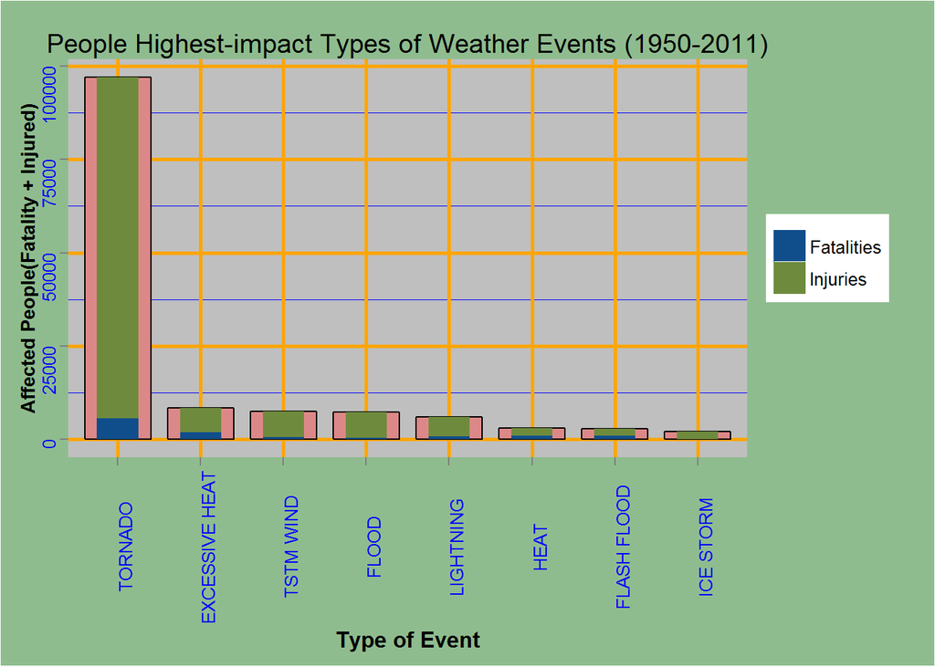

```r
# Reorder by people impact
  library(dplyr)
  sample=head(arrange(sumed, desc(AffectedPeople)),8)

# For ggplot, the X axis needs to be explicily reordered to show the bars
# in order of size
  sample$EVTYPE = with(sample,reorder(EVTYPE,AffectedPeople))

  library(reshape2)
  melted=melt(sample,id=c("EVTYPE"),measure.vars=c("Fatalities","Injuries"))
  colnames(melted)=c("EvType","Impact","AffectedPeople")

# Produce the plot for top 8 events
# Did two barplots in the same grid: One with the total and another with the
# stacked bar
  library(ggplot2)
  ggplot(data=sample, aes(x=EVTYPE, y=AffectedPeople)) +
        geom_bar(colour="black", fill="#DD8888", width=.8,stat="identity")+
        ggtitle("People Highest-impact Types of Weather Events (1950-2011)") +
        ylab("Affected People(Fatality + Injured)") +
        xlab("Type of Event") +
        scale_x_discrete(limits=rev(levels(sample$EVTYPE))) +
        geom_bar(aes(x=melted$EvType,y=melted$AffectedPeople,
                     fill=melted$Impact),stat="identity",width=.5)+
        scale_fill_manual(values=c("dodgerblue4", "darkolivegreen4",
                              "darkorchid3", "goldenrod1")) +
        theme(panel.background = element_rect(fill = 'grey75'),
              plot.background=element_rect(fill="darkseagreen"),
              panel.grid.major = element_line(colour = "orange", size=1),
              panel.grid.minor = element_line(colour = "blue"),
              legend.title=element_blank(),
              axis.title.x = element_text(face="bold"),
              axis.title.y = element_text(face="bold",size=10),
              axis.text.x = element_text(angle=90, vjust=1,colour="blue"),
              axis.text.y = element_text(angle=90, vjust=1,colour="blue"))
```

Other events that unfortunately lead to the most fatalities and injured people are, in that order, **Excessive Heat, Thunderstorms with Wind, Floods, Lightning storms, Heat, Flash floods and Ice Storms**. These are the events for which authorities should prepare the most in terms of public health planning.

## Economic Impact

When looking at weather events in terms of economic damage (destroyed private property, loss of farm crops), the findings vary significantly:

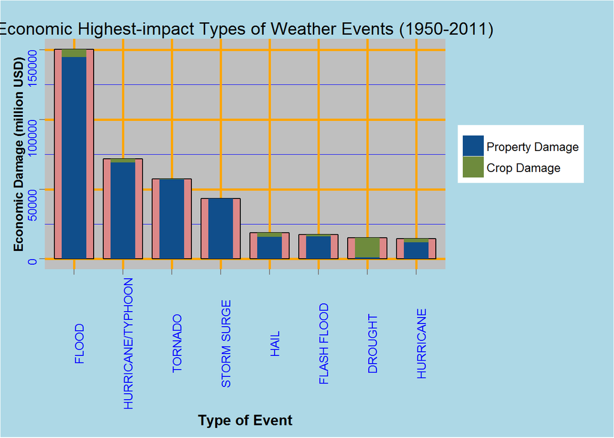

```r
# Reorder by people impact
  library(dplyr)
  sample=head(arrange(sumed, desc(SumDamage)),8)
  sample=mutate(sample,PropDamage=PropDamage/1e+6,
                CropDamage=CropDamage/1e+6,
                SumDamage=SumDamage/1e+6)

# For ggplot, the X axis needs to be explicily reordered to show the bars
# in order of size
  sample$EVTYPE = with(sample,reorder(EVTYPE,SumDamage))

  library(reshape2)
  melted=melt(sample,id=c("EVTYPE"),measure.vars=c("PropDamage","CropDamage"))
  colnames(melted)=c("EvType","Impact","EconomicDamage")

# Produce the plot for top 8 events
# Did two barplots in the same grid: One with the total and another with the
# stacked bar
  library(ggplot2)
  ggplot(data=sample, aes(x=EVTYPE, y=SumDamage)) +
        geom_bar(colour="black", fill="#DD8888", width=.8,stat="identity")+
        ggtitle("Economic Highest-impact Types of Weather Events (1950-2011)") +
        ylab("Economic Damage (million USD)") +
        xlab("Type of Event") +
        scale_x_discrete(limits=rev(levels(sample$EVTYPE))) +
        geom_bar(aes(x=melted$EvType,y=melted$EconomicDamage,
                     fill=melted$Impact),stat="identity",width=.5)+
        scale_fill_manual(values=c("dodgerblue4", "darkolivegreen4",
                              "darkorchid3", "goldenrod1"),
                          labels=c("Property Damage","Crop Damage")) +
        theme(panel.background = element_rect(fill = 'grey75'),
              plot.background=element_rect(fill="lightblue"),
              panel.grid.major = element_line(colour = "orange", size=1),
              panel.grid.minor = element_line(colour = "blue"),
              legend.title=element_blank(),
              axis.title.x = element_text(face="bold"),
              axis.title.y = element_text(face="bold",size=10),
              axis.text.x = element_text(angle=90, vjust=1,colour="blue"),
              axis.text.y = element_text(angle=90, vjust=1,colour="blue"))
```

What the above suggests is that water-related events such as **floods and hurricanes** are the most damaging events for the economy of the country. In particular, floods alone have caused economic damages for over **150 billion USD** in the 60-year period under analysis. It also can be seen that the damage to property (buildings, infrastructure) is the highest in most of the cases. On the other hand, drought is the most damaging weather condition for farmers.